# Fasting Weights

Modelling my weight when fasting

true  
May 14, 2021

Loading the data

```r
library(readr)
library(effects)
library(lme4)
library(ggplot2)
library(splines)
library(kableExtra)
library(dplyr)
library(directlabels)
library(mgcv)
library(mgcViz)

def_th <- theme_bw() +
        theme( legend.position = "none",
               plot.caption = element_text( vjust = 0,
                                            hjust = 0#,
                                            #margin(t=15)
                                            ),
               text = element_text( family = "serif"))

fast_sleep      <- read_delim("fast_sleep_data.txt",
                              "\t",
                              escape_double = FALSE,
                              locale = locale(date_format   = "%Y.%m.%d",                                                                  decimal_mark  = ",",
                                              grouping_mark = ""),
                              trim_ws = TRUE)

fast_sleep$time <- as.numeric(
                     fast_sleep$Day_offset * 24 * 3600 +
                     fast_sleep$Time_of_measurement -
                     fast_sleep$Finished_eating
                   ) / 3600

fast_sleep$twu     <- as.numeric(fast_sleep$Time_of_measurement - fast_sleep$Woke_up) / 3600
fast_sleep$twu     <- ifelse( fast_sleep$twu > fast_sleep$time, fast_sleep$time, fast_sleep$twu)
fast_sleep         <- fast_sleep[is.na(fast_sleep$Mass)==FALSE,]
fast_sleep$change  <- fast_sleep$Mass - fast_sleep$Last_fed_weight
fast_sleep$date    <- as.numeric( difftime( fast_sleep$Date_beginning + fast_sleep$Day_offset, fast_sleep$Date_beginning[1])/ (24*3600))
fast_sleep$Episode <- as.factor( fast_sleep$Episode)
fast_sleep$truedate <- fast_sleep$date + lubridate::hour(fast_sleep$Time_of_measurement)/24
```

Visualizing with “pairs” looking for patterns

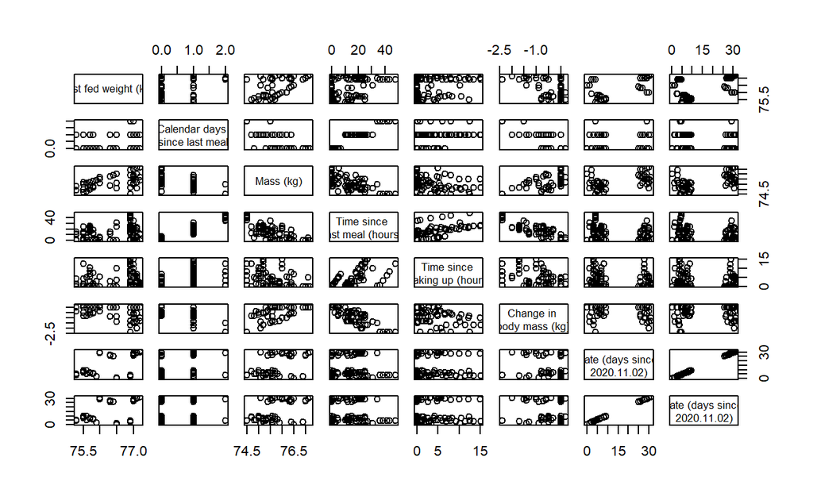

```r
fsn <- fast_sleep[ , unlist(lapply(fast_sleep, is.numeric)) == TRUE]
fsn <- fsn[ , -4]
colnames(fsn) <- c("Last fed weight (kg)",
                   "Calendar days \nsince last meal",
                   "Mass (kg)",
                   "Time since \nlast meal (hours)",
                   "Time since \nwaking up (hours)",
                   "Change in \nbody mass (kg)",
                   "Date (days since \n2020.11.02)",
                   "Date (days since \n2020.11.02)")
pairs( fsn)
```

Making a correlaton matrix.

```r
cor( fsn) %>%
  kbl( digits = 2) %>%
  kable_minimal()
```

|  | Last fed weight (kg) | Calendar days since last meal | Mass (kg) | Time since last meal (hours) | Time since waking up (hours) | Change in body mass (kg) | Date (days since 2020.11.02) | Date (days since 2020.11.02) |
| --- | --- | --- | --- | --- | --- | --- | --- | --- |
| Last fed weight (kg) | 1.00 | 0.26 | 0.39 | 0.31 | 0.21 | -0.55 | 0.48 | 0.48 |
| Calendar days since last meal | 0.26 | 1.00 | -0.65 | 0.92 | 0.37 | -0.82 | -0.14 | -0.15 |
| Mass (kg) | 0.39 | -0.65 | 1.00 | -0.65 | -0.31 | 0.56 | 0.54 | 0.55 |
| Time since last meal (hours) | 0.31 | 0.92 | -0.65 | 1.00 | 0.61 | -0.86 | -0.18 | -0.18 |
| Time since waking up (hours) | 0.21 | 0.37 | -0.31 | 0.61 | 1.00 | -0.47 | -0.12 | -0.11 |
| Change in body mass (kg) | -0.55 | -0.82 | 0.56 | -0.86 | -0.47 | 1.00 | 0.06 | 0.06 |
| Date (days since 2020.11.02) | 0.48 | -0.14 | 0.54 | -0.18 | -0.12 | 0.06 | 1.00 | 1.00 |
| Date (days since 2020.11.02) | 0.48 | -0.15 | 0.55 | -0.18 | -0.11 | 0.06 | 1.00 | 1.00 |

Plotting the main interest

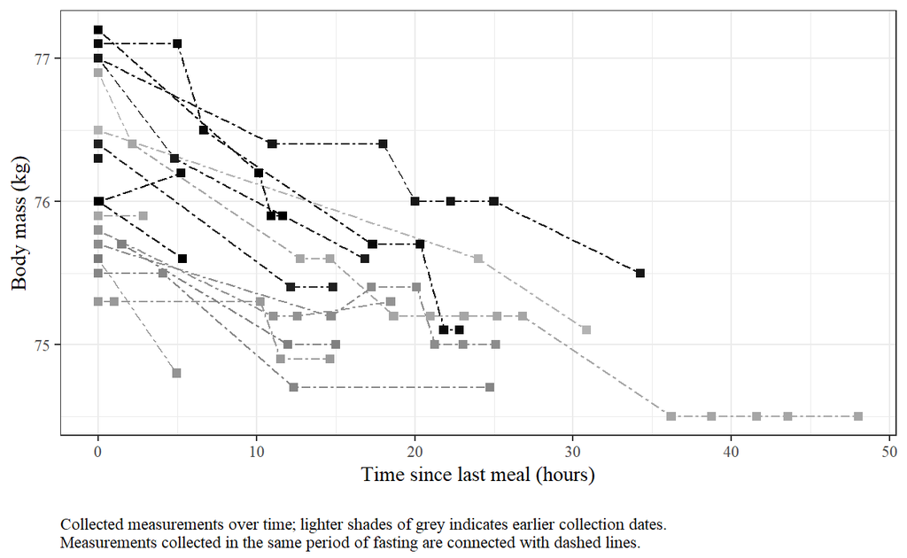

```r
ggplot(fast_sleep, aes( x = time, y = Mass, group = Episode, color = Date_beginning)) +
  theme_bw() +
  theme( legend.position = "none",
         plot.caption =  element_text(vjust = .0, hjust = .0, margin=margin(t=15)),
         text = element_text(family = "serif")) +
  geom_line(size = .5, linetype = "twodash") +
  geom_point( shape = 15, size = 1.8) +
  scale_color_gradient( low="gray70",high="black") +
  xlab( "Time since last meal (hours)") +
  ylab( "Body mass (kg)") +
  labs(caption = "Collected measurements over time; lighter shades of grey indicates earlier collection dates.
Measurements collected in the same period of fasting are connected with dashed lines.")
```

Plotting the sparsity of the observations

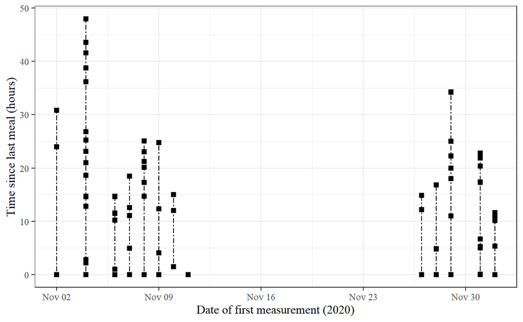

```r
ggplot(fast_sleep, aes( x = Date_beginning, y = time, group = Episode)) +
  theme_bw() +
  theme( legend.position = "none",
         plot.caption =  element_text(vjust = .0, hjust = .0, margin=margin(t=15)),
         text = element_text(family = "serif")) +
  geom_line(size = .5, linetype = "twodash") +
  geom_point( shape = 15, size = 1.8) +
  xlab( "Date of first measurement (2020)") +
  ylab( "Time since last meal (hours)")
```

```r
  #geom_hline(yintercept=24, color = "salmon4")
  #labs(caption = "Distribution of measurements in the data collection period.")
```

### (Initial) investigations with GAM

Beginning with a gam() model.

```r
# fsnn <- fast_sleep # as in "fast_sleep_nice_names"

# colnames(fsnn) <- c("Date of first measurement (2020)",
#                     "No. of measured fasting episode",
#                     "Time of waking up",
#                     "Time of the end of last meal",
#                    "Last fed weight (kg)",
#                    "Calendar days since last meal",
#                    "Mass (kg)",
#                    "Blood glucose (mmol/ml)",
#                    "Time since last meal (hours)",
#                    "Time since waking up (hours)",
#                    "Change in body mass (kg)",
#                    "Date (days since 2020.11.02)")
#
# mod_gam <- gam(Mass ~ s("Time since last meal (hours)", bs = "ts") +
#                       s("Date (days since 2020.11.02)", bs = "ts") +
#                       s("Last fed weight (kg)", bs = "ts") +
#                       s("Time since waking up (hours)", bs = "ts"),
#                data = fsnn)

mod_gam <- gam(Mass ~ s(time, bs = "ts") +
                      s(truedate, bs = "ts") +
                      s(Last_fed_weight, bs = "ts") +
                      s(twu, bs = "ts"),
               data = fast_sleep)

mod_gam
```

```
Family: gaussian
Link function: identity

Formula:
Mass ~ s(time, bs = "ts") + s(truedate, bs = "ts") + s(Last_fed_weight,
    bs = "ts") + s(twu, bs = "ts")

Estimated degrees of freedom:
2.012 7.176 1.216 0.713  total = 12.12

GCV score: 0.07056902
```

```r
viz <- getViz(mod_gam)
anova(mod_gam)
```

```
Family: gaussian
Link function: identity

Formula:
Mass ~ s(time, bs = "ts") + s(truedate, bs = "ts") + s(Last_fed_weight,
    bs = "ts") + s(twu, bs = "ts")

Approximate significance of smooth terms:
                      edf Ref.df      F  p-value
s(time)            2.0123 9.0000 20.879  < 2e-16
s(truedate)        7.1762 9.0000  4.471 1.58e-05
s(Last_fed_weight) 1.2159 9.0000  5.757  < 2e-16
s(twu)             0.7131 9.0000  0.229   0.0836
```

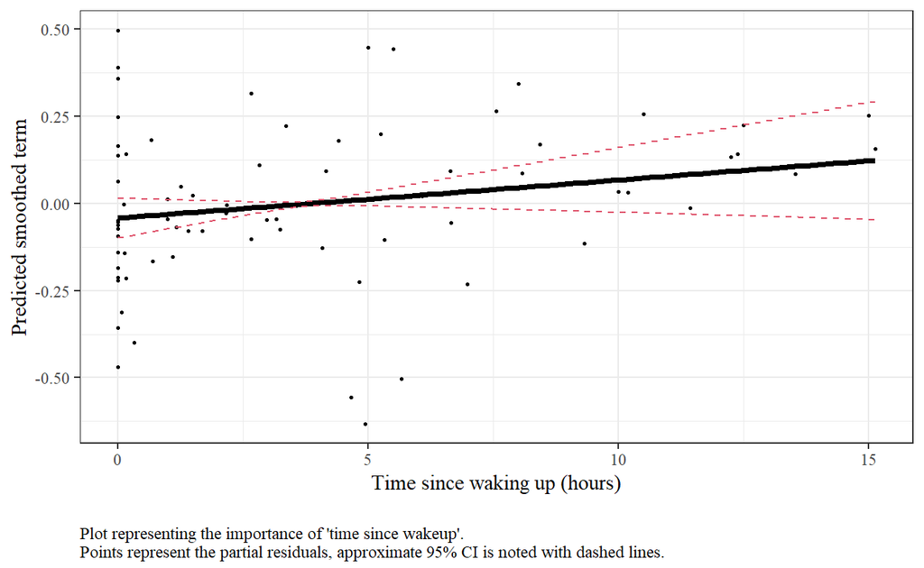

```r
p <- plot(viz, allTerms = F, select = 4) +
  theme_bw() +
  theme( legend.position = "none",
         plot.caption =  element_text(vjust = .0, hjust = .0, margin=margin(t=15)),
         text = element_text(family = "serif")) +
  l_points(shape = 19, size = .5, alpha = 1) +
  l_fitLine( size = 1.3) +
  l_ciLine(colour = 2) +
  xlab("Time since waking up (hours)") +
  ylab("Predicted smoothed term") +
  labs( caption = "Plot representing the importance of 'time since wakeup'.
Points represent the partial residuals, approximate 95% CI is noted with dashed lines.")


print(p, pages = 1)
```

Based on the (approximate) ANOVA table, small absolute contribution of the term to the dependent variable, it may be omitted.

```r
mod_gam <- gam(Mass ~ s(time, bs = "ts") +
                      s(truedate, bs = "ts") +
                      s(Last_fed_weight, bs = "ts"),
               data = fast_sleep)

anova(mod_gam)
```

```
Family: gaussian
Link function: identity

Formula:
Mass ~ s(time, bs = "ts") + s(truedate, bs = "ts") + s(Last_fed_weight,
    bs = "ts")

Approximate significance of smooth terms:
                     edf Ref.df      F  p-value
s(time)            1.879  9.000 23.411  < 2e-16
s(truedate)        7.056  9.000  4.424 1.68e-05
s(Last_fed_weight) 1.104  9.000  5.503  < 2e-16
```

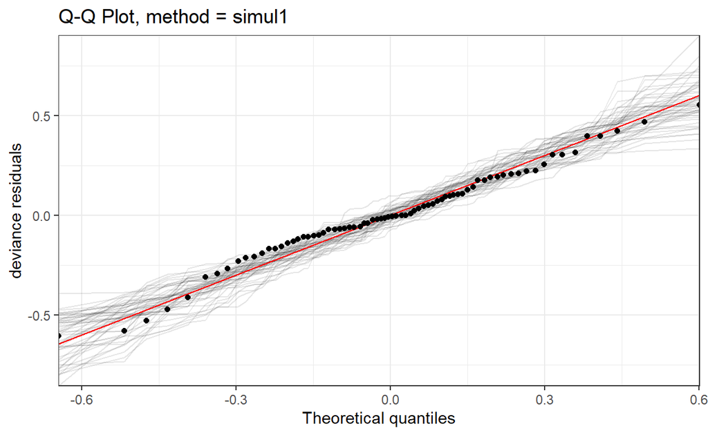

```r
viz <- getViz(mod_gam)


qq(viz, rep = 50, showReps = T, CI = "none",
   a.qqpoi = list("shape" = 19),
   a.replin = list("alpha" = 0.1))
```

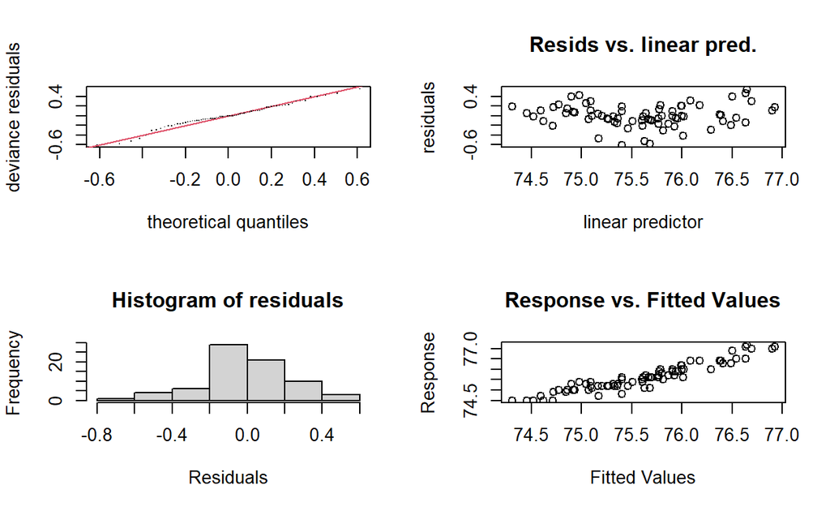

```
Method: GCV   Optimizer: magic
Smoothing parameter selection converged after 14 iterations.
The RMS GCV score gradient at convergence was 3.286781e-06 .
The Hessian was positive definite.
Model rank =  28 / 28

Basis dimension (k) checking results. Low p-value (k-index<1) may
indicate that k is too low, especially if edf is close to k'.

                     k'  edf k-index p-value
s(time)            9.00 1.88    1.12   0.820
s(truedate)        9.00 7.06    0.83   0.035 *
s(Last_fed_weight) 9.00 1.10    0.86   0.110
---
Signif. codes:  0 '***' 0.001 '**' 0.01 '*' 0.05 '.' 0.1 ' ' 1
```

```r
par(mfcol=c(2,2))
gam.check(mod_gam)
```

```r
par(mfcol=c(1,1))
```

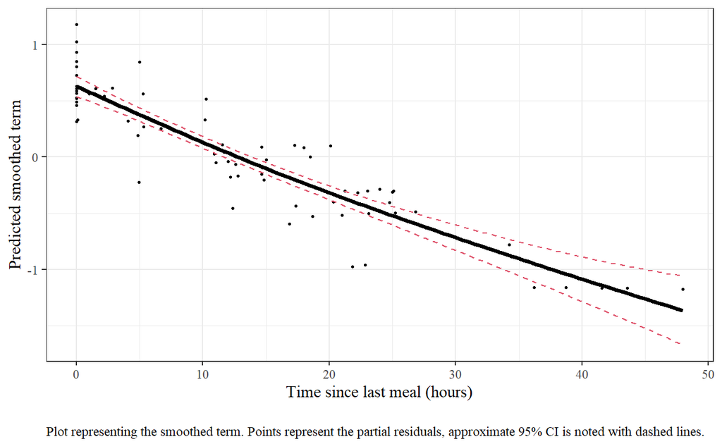

(#fig:gam_fasttime_plot)Change in body weight as a function of hours fasted

```r
p <- plot(viz, allTerms = F, select = 1) +
  theme_bw() +
  theme( legend.position = "none",
         plot.caption =  element_text(vjust = .0, hjust = .0, margin=margin(t=15)),
         text = element_text(family = "serif")) +
  l_points(shape = 19, size = .5, alpha = 1) +
  l_fitLine( size = 1.3) +
  l_ciLine(colour = 2) +
  xlab("Time since last meal (hours)") +
  ylab("Predicted smoothed term") +
  labs( caption = "Plot representing the smoothed term. Points represent the partial residuals, approximate 95% CI is noted with dashed lines.")


print(p, pages = 1)
```

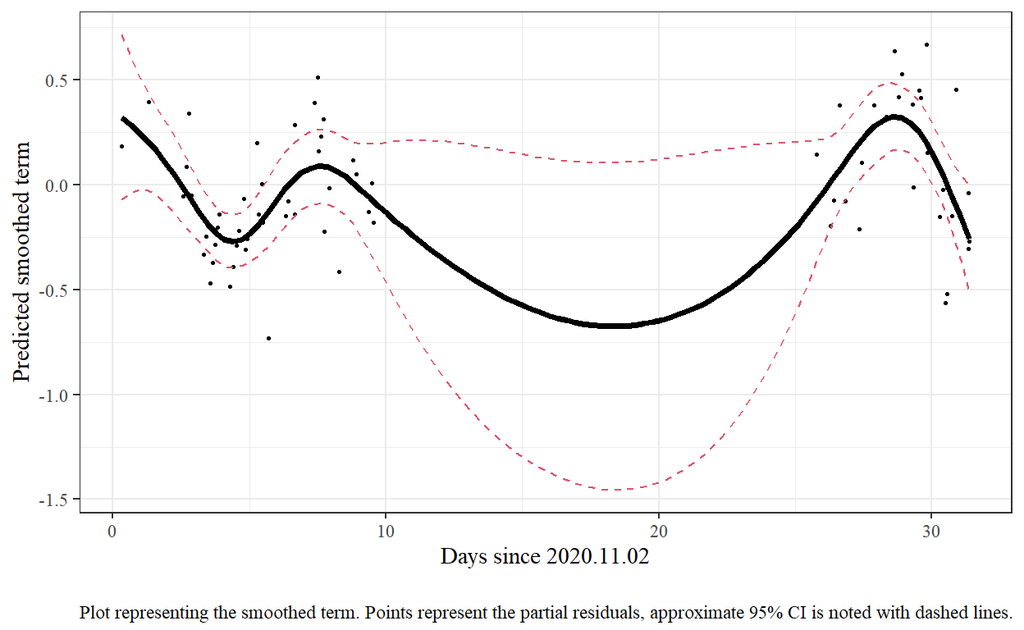

(#fig:gam_calendar_plot)Change in body weight at different days

```r
p <- plot(viz, allTerms = F, select = 2) +
  theme_bw() +
  theme( legend.position = "none",
         plot.caption =  element_text(vjust = .0, hjust = .0, margin=margin(t=15)),
         text = element_text(family = "serif")) +
  l_points(shape = 19, size = .5, alpha = 1) +
  l_fitLine( size = 1.3) +
  l_ciLine(colour = 2) +
  xlab("Days since 2020.11.02") +
  ylab("Predicted smoothed term") +
  labs( caption = "Plot representing the smoothed term. Points represent the partial residuals, approximate 95% CI is noted with dashed lines.")


print(p, pages = 1)
```

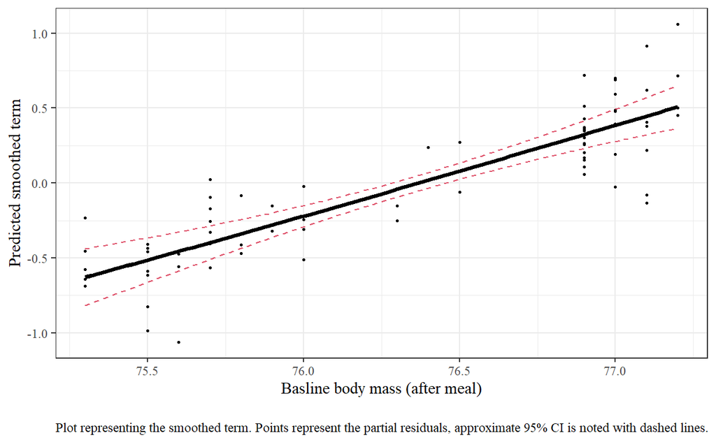

(#fig:gam_baseline_plot)Effect of baseline body weight (at the beginning of a fast)

```r
p <- plot(viz, allTerms = F, select = 3) +
  theme_bw() +
  theme( legend.position = "none",
         plot.caption =  element_text(vjust = .0, hjust = .0, margin=margin(t=15)),
         text = element_text(family = "serif")) +
  l_points(shape = 19, size = .5, alpha = 1) +
  l_fitLine( size = 1.3) +
  l_ciLine(colour = 2) +
  xlab("Basline body mass (after meal)") +
  ylab("Predicted smoothed term") +
  labs( caption = "Plot representing the smoothed term. Points represent the partial residuals, approximate 95% CI is noted with dashed lines.")


print(p, pages = 1)
```

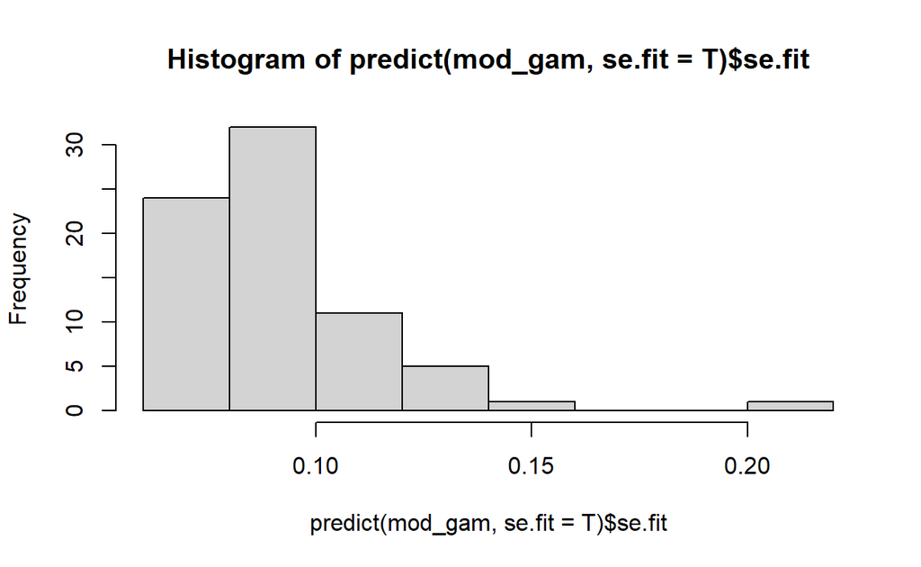

```r
hist(predict(mod_gam, se.fit=T)$se.fit)
```

### Change vs. not change

A quick example that in cases of “baseline correction”, modelling “change” or the variable itself leads to the same results.

That the change in body mass would be a function of the date is peculiar to say the least…

Note that the tolerance intervals are quite large. However we are interested in the variability of the *effect* (which is in this case represents the ‘true’ weight as far as we can measure it).

We have hacked splines with roughly the same ‘wriggliness’ as in the GAM model for now.

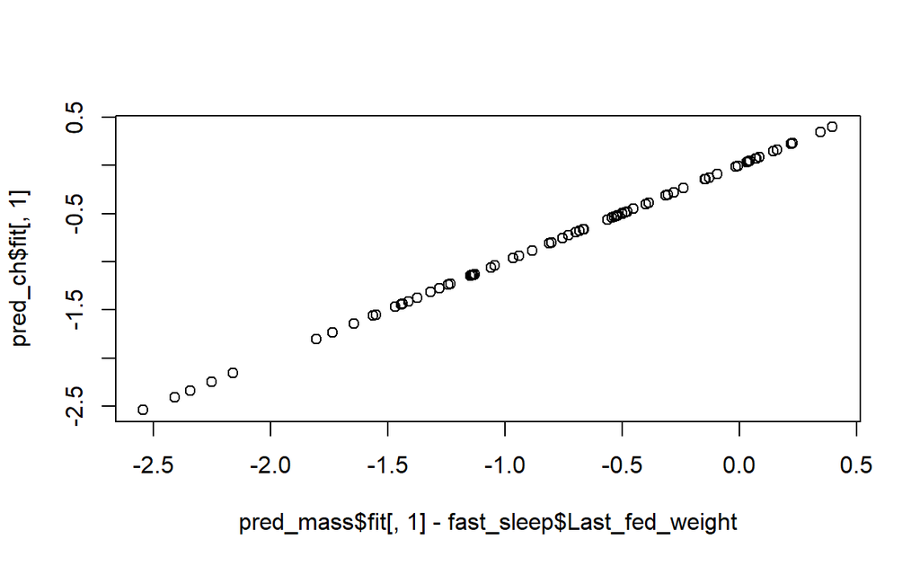

```r
mod_mass <- lm( Mass ~Last_fed_weight +  ns( time, df = 2) + ns( truedate, df = 7),
                 fast_sleep)

mod_ch   <- lm( change ~ Last_fed_weight + ns( time, df = 2) + ns( truedate, df = 7), fast_sleep)

pred_mass <- predict(mod_mass, se.fit = TRUE, interval = 'prediction')
pred_ch   <- predict(mod_ch, se.fit = TRUE, interval = 'prediction')

plot(pred_mass$fit[,1] - fast_sleep$Last_fed_weight, pred_ch$fit[,1])
```

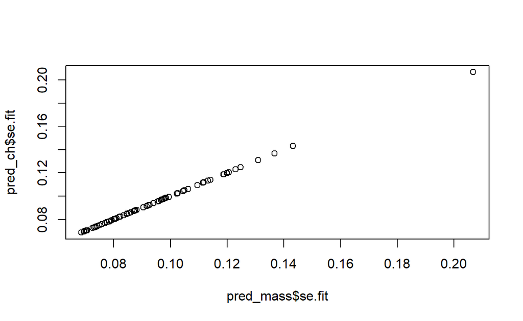

```r
plot(pred_mass$se.fit, pred_ch$se.fit) # avg. SE
```

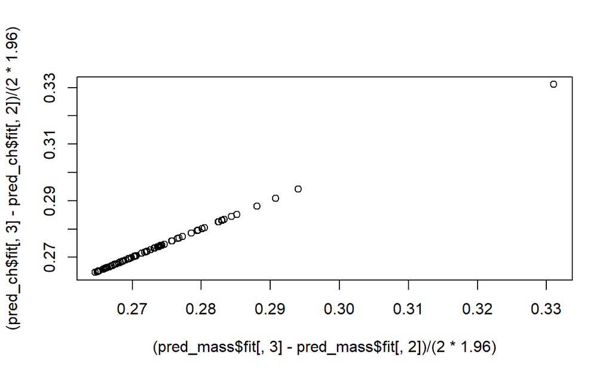

```r
plot((pred_mass$fit[,3] - pred_mass$fit[,2])/(2*1.96),
     (pred_ch$fit[,3] - pred_ch$fit[,2])/(2*1.96)) # predict.intervals
```

## Mixed modelling

Let’s see what we can do with mixed models! I’ll try to select a random intercept/slope model (without correlation between the terms). Models with high multicollinearity (VIF>10) should be shunned. Model selection is done via AIC and BIC values.

```r
library(splines)

Spline_BIC <- expand.grid(
                   time = 0:3,
                   twu  = 0:0,
                   lfw  = 0:3,
                   dat  = 0:10,
                   interact = c(F),
                   BIC  = 0,
                   AIC  = 0,
                   VIF  = 0,
                   f = "")
Spline_BIC$f <- as.character(Spline_BIC$f)
pb   <- txtProgressBar()

for ( i in 1:nrow(Spline_BIC)) {

  #####
  ###Generáljuk a "formulát"
  f1 <- ifelse( Spline_BIC$time[i] == 0,
                paste( "Mass ~ "),
                paste( "Mass ~ ns(time,",
                       Spline_BIC$time[i],
                      ")"))
  f2 <- ifelse( Spline_BIC$interact[i] == TRUE, "*", "+")

  f3 <- ifelse( Spline_BIC$dat[i] == 0, "",
                paste( " ns(truedate,",
                       Spline_BIC$dat[i],")"))

  f4 <- ifelse( Spline_BIC$lfw[i] == 0, "",
                paste( " + ns(Last_fed_weight,",
                       Spline_BIC$lfw[i],")"))

  f5 <- ifelse( Spline_BIC$twu[i] == 0, "",
                paste( " + ns(twu,",
                       Spline_BIC$twu[i],")"))


  f <- paste(f1,f2,f3,f4,f5, "+(time||Episode)")
  Spline_BIC$f[i] <- f
  f       <- as.formula(f)
  #####

  .b <- -1000
  .a <- -1000
  try( silent = TRUE, expr = {
    m <- lmer( f,
              data = fast_sleep)
    .b <- BIC(m)
    .a <- AIC(m)
    .v <- max(car::vif(m))
    Spline_BIC$BIC[i] <- .b
    Spline_BIC$AIC[i] <- .a
    Spline_BIC$VIF[i] <- .v
  })

  setTxtProgressBar(pb, i/nrow(Spline_BIC))

}
close(pb)
```

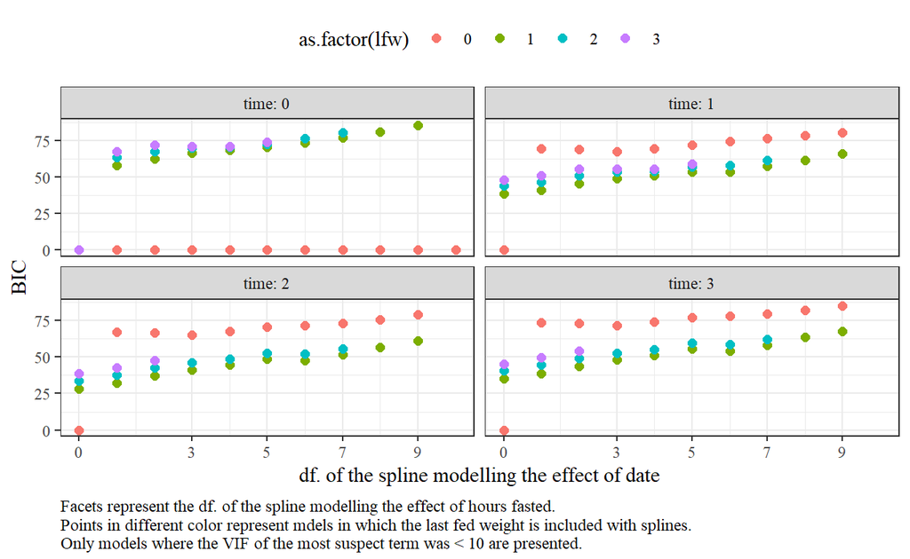

```r
Spline_BIC <- Spline_BIC[Spline_BIC$BIC != -1000,]

Spline_BIC %>%
  .[Spline_BIC$VIF < 10,] %>%
    ggplot( ., aes( x = dat, y = BIC, group = interact, color = as.factor(lfw))) +
      def_th +
  theme(legend.position = 'top') +
      geom_point(size=2) +
      facet_wrap(facets="time", labeller = label_both) +
      scale_x_continuous(breaks=c(0,3,5,7,9)) +
      xlab("df. of the spline modelling the effect of date") +
  labs(caption="Facets represent the df. of the spline modelling the effect of hours fasted.
Points in different color represent mdels in which the last fed weight is included with splines.
Only models where the VIF of the most suspect term was < 10 are presented.")
```

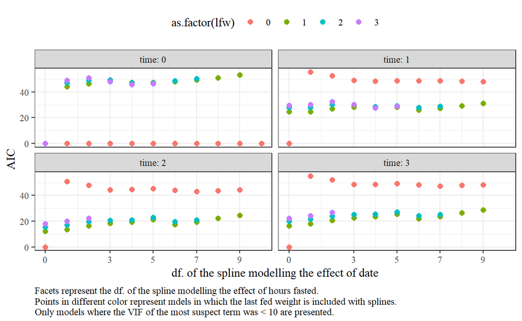

```r
Spline_BIC %>%
  .[Spline_BIC$VIF < 10,] %>%
    ggplot( ., aes( x = dat, y = AIC, group = interact, color = as.factor(lfw))) +
      def_th +
      theme(legend.position = 'top') +
      geom_point(size=2) +
      facet_wrap(facets="time", labeller = label_both) +
      scale_x_continuous(breaks=c(0,3,5,7,9)) +
      xlab("df. of the spline modelling the effect of date") +
  labs(caption="Facets represent the df. of the spline modelling the effect of hours fasted.
Points in different color represent mdels in which the last fed weight is included with splines.
Only models where the VIF of the most suspect term was < 10 are presented.")
```

Based on both AIC and BIC values, the date of the fasting period should be omitted (this is logical, but it is in contrast with the GAM suggestion), and the duration of the fast should be included with a spine (df=2).

It seems that the model diagnostics are acceptable. There is some minor autocorrelation, which I think is due to the fact that each episode is ~4 observations long. There is perhaps a correlation between the intercept/slope of the random effects.

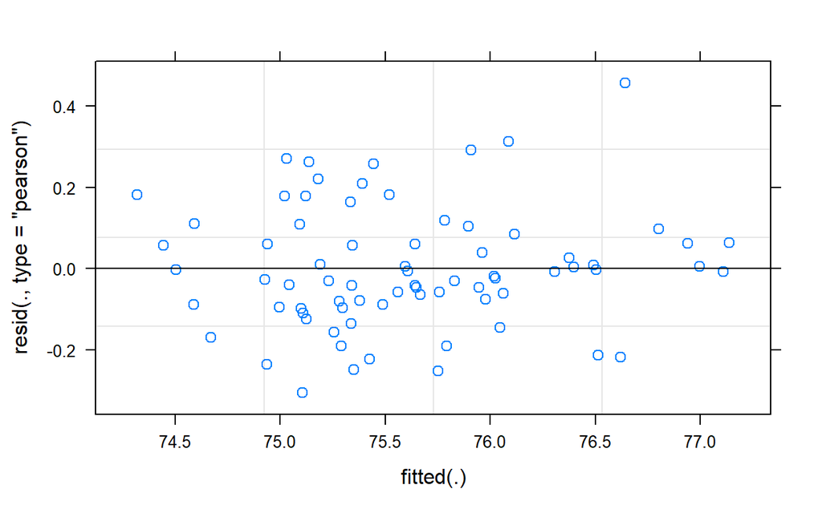

```r
mod_lmer   <- lmer( Mass ~ Last_fed_weight + ns( time, df = 2) #+ ns( truedate, df = 6)
                   + (time||Episode),
                  fast_sleep)
plot(mod_lmer)
```

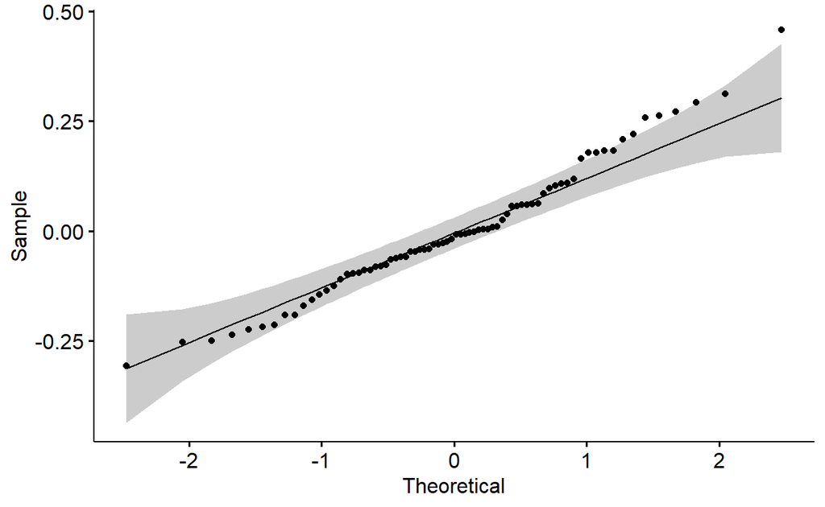

```r
ggpubr::ggqqplot(residuals(mod_lmer))
```

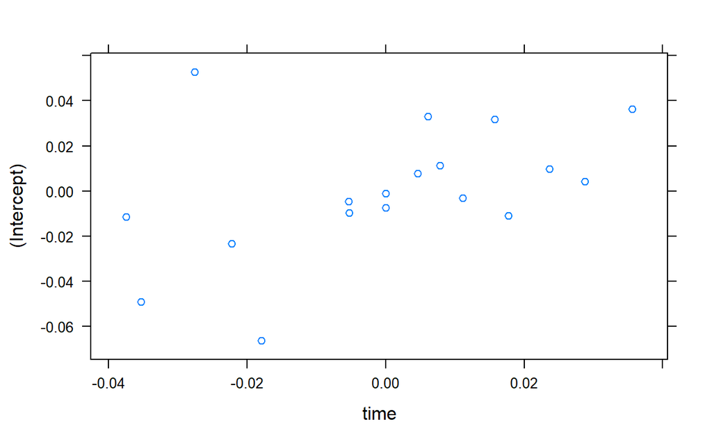

```r
plot(ranef(mod_lmer))
```

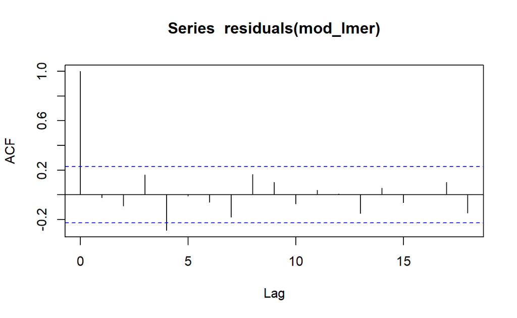

```r
acf(residuals(mod_lmer))
```

```r
car::vif(mod_lmer)
```

```
                     GVIF Df GVIF^(1/(2*Df))
Last_fed_weight  1.048078  1        1.023757
ns(time, df = 2) 1.048078  2        1.011809
```

```r
confint(mod_lmer, method = 'boot', nsim = 1000, boot.type = 'norm', oldNames = FALSE)
```

```
                             2.5 %      97.5 %
sd_(Intercept)|Episode -0.03711017  0.17439051
sd_time|Episode         0.01434167  0.03917232
sigma                   0.14145161  0.20984878
(Intercept)            -3.59005455 13.94826151
Last_fed_weight         0.81710284  1.04732071
ns(time, df = 2)1      -3.05985363 -1.59739379
ns(time, df = 2)2      -1.89244237 -0.40391503
```

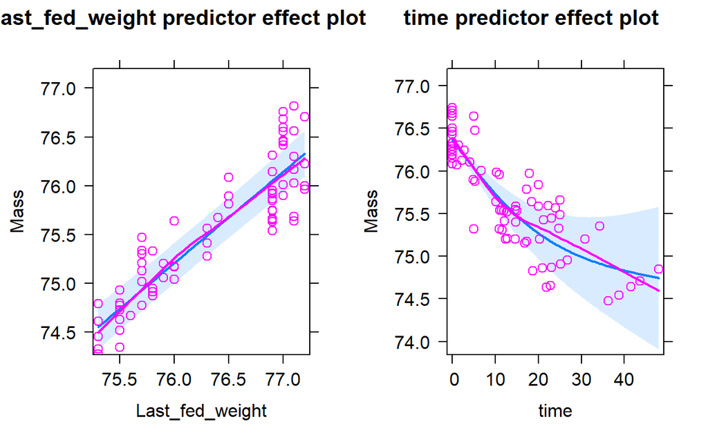

```r
plot(predictorEffects(mod_lmer, residuals = TRUE))
```

The correlation of the slopes and intercepts don’t bring any marked improvements. The residuals are less optimal when a correlated model is introduced.

```r
mod_cor   <- lmer( Mass ~ Last_fed_weight + ns( time, df = 2) #+ ns( truedate, df = 6)
                   + ( time|Episode),
                  fast_sleep)

anova( mod_lmer, mod_cor)
```

```
Data: fast_sleep
Models:
mod_lmer: Mass ~ Last_fed_weight + ns(time, df = 2) + ((1 | Episode) +
mod_lmer:     (0 + time | Episode))
mod_cor: Mass ~ Last_fed_weight + ns(time, df = 2) + (time | Episode)
         npar    AIC    BIC logLik deviance  Chisq Df Pr(>Chisq)
mod_lmer    7 3.1757 19.304 5.4122  -10.824
mod_cor     8 4.5925 23.025 5.7038  -11.408 0.5832  1     0.4451
```

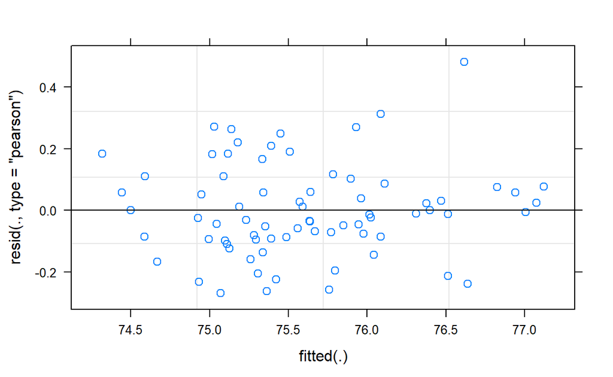

```r
plot(mod_cor)
```

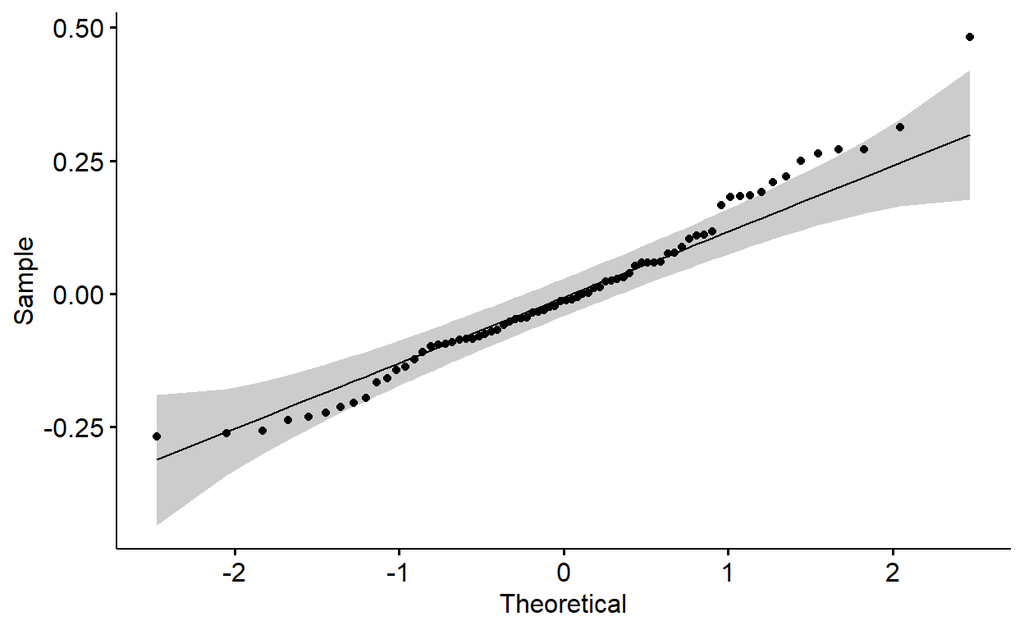

```r
ggpubr::ggqqplot(residuals(mod_cor))
```

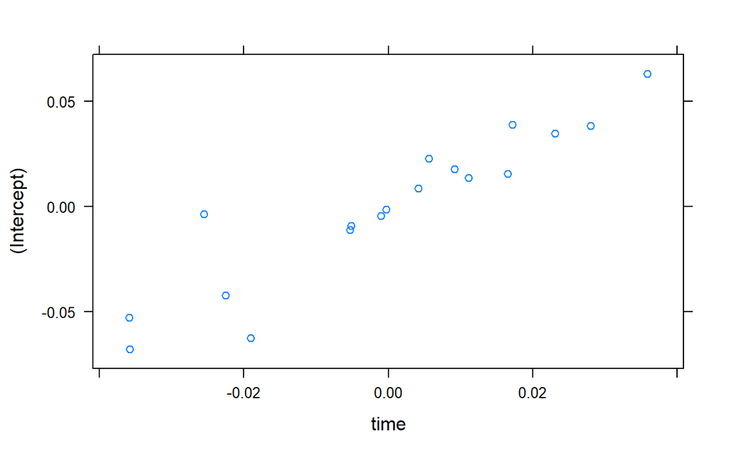

```r
plot(ranef(mod_cor))
```

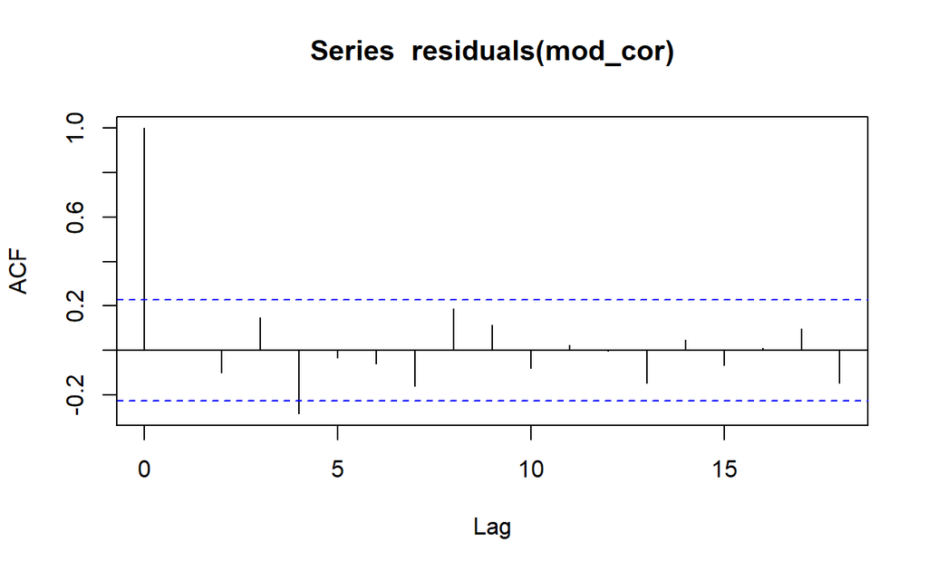

```r
acf(residuals(mod_cor))
```

```r
car::vif(mod_cor)
```

```
                     GVIF Df GVIF^(1/(2*Df))
Last_fed_weight  1.068864  1        1.033859
ns(time, df = 2) 1.068864  2        1.016789
```

```r
confint(mod_cor, method = 'boot', nsim = 1000, boot.type = 'norm', oldNames = FALSE)
```

```
                                   2.5 %      97.5 %
sd_(Intercept)|Episode       -0.04763432  0.14096210
cor_time.(Intercept)|Episode -0.41245485  1.74400139
sd_time|Episode               0.01329656  0.03697421
sigma                         0.14232319  0.21198733
(Intercept)                  -6.16365988 12.14029245
Last_fed_weight               0.84084179  1.08116712
ns(time, df = 2)1            -3.04419331 -1.60977146
ns(time, df = 2)2            -1.85719863 -0.38567620
```

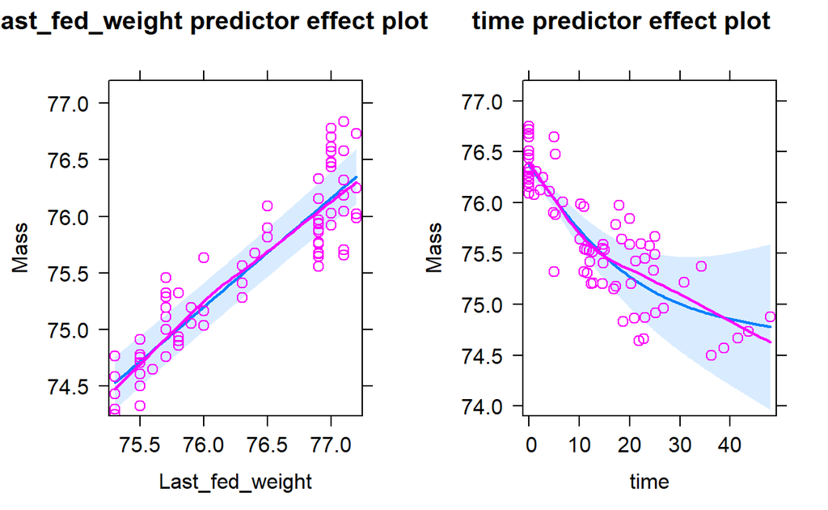

```r
plot(predictorEffects(mod_cor, residuals = TRUE))
```

Showing the effect plots and the random effects.

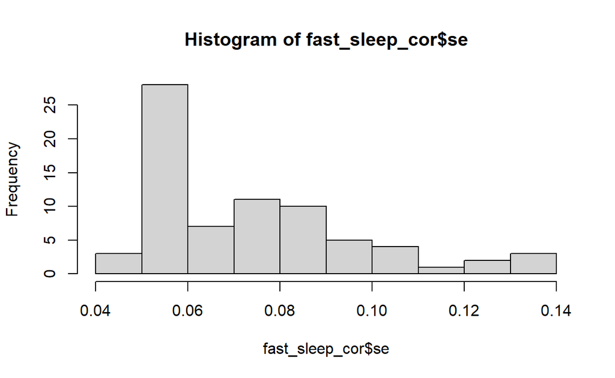

```r
library(merTools)
set.seed(1234)

fast_sleep_cor <- fast_sleep
fast_sleep_cor$pred <- predict( mod_lmer)


predFun <- function(fit) {
  predict(fit,allow.new.levels=FALSE)
}

bb <- bootMer(mod_lmer, nsim=300, FUN=predFun, seed=2718,
              use.u=TRUE, # Conditional on observed random effects!
              type="parametric")

fast_sleep_cor <- t( sapply(1:nrow(fast_sleep),
                            function(x)quantile(bb$t[,x],
                                                c(.025,.5,.975)))) %>%
                    cbind(fast_sleep_cor, .)

colnames( fast_sleep_cor)[(ncol(fast_sleep_cor)-2):
                            (ncol(fast_sleep_cor))] <- c("bootlwr",
                                                         "bootmed",
                                                         "bootupr")

fast_sleep_cor$se <- with( fast_sleep_cor, (bootupr-bootlwr)/(2*1.96))

hist(fast_sleep_cor$se)
```

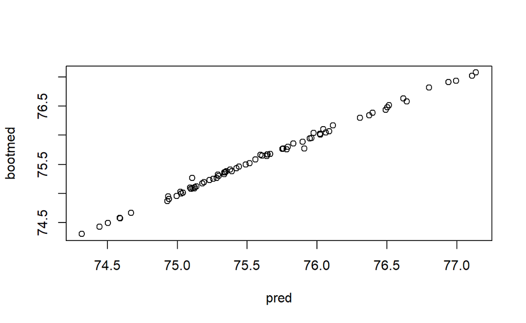

```r
with( fast_sleep_cor, plot(pred,bootmed))
```

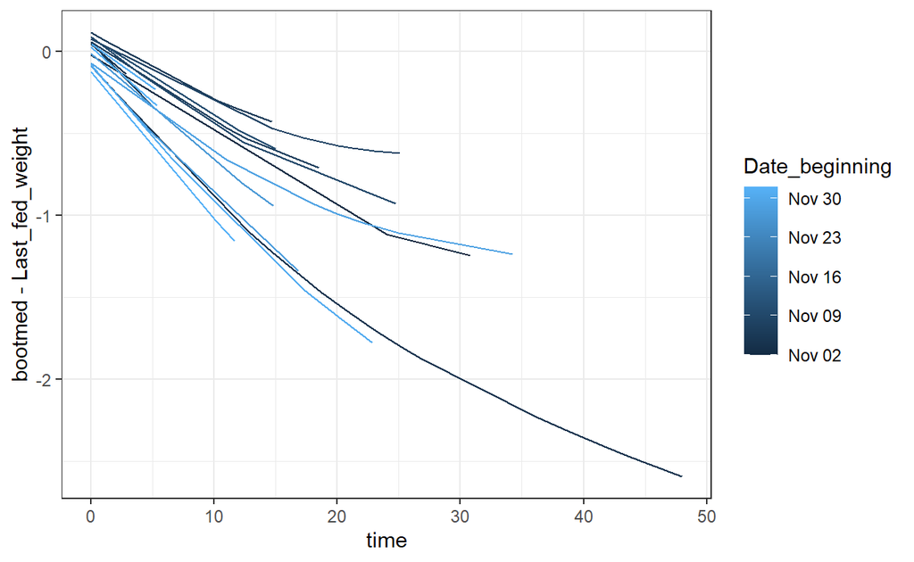

```r
ggplot( fast_sleep_cor, aes( x = time,
                             y = bootmed - Last_fed_weight,
                             group = Episode,
                             color = Date_beginning)) +
  theme_bw() +
  geom_line()
```

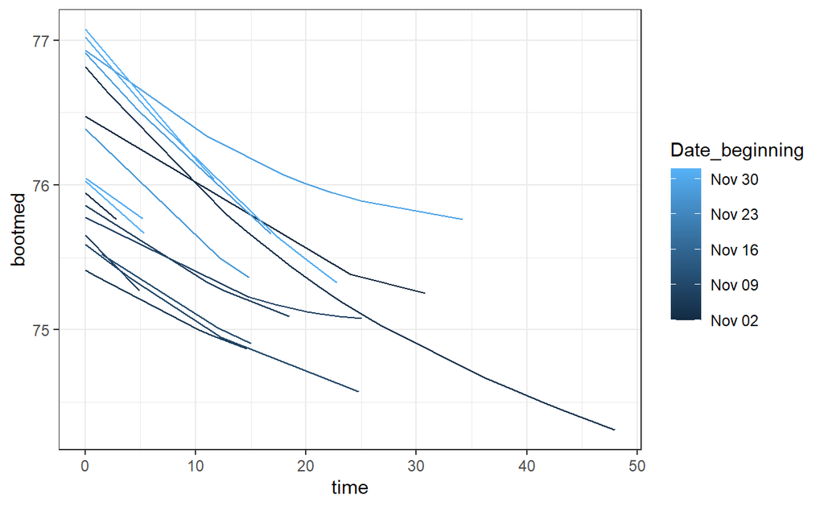

```r
ggplot( fast_sleep_cor, aes( x = time,
                             y = bootmed,
                             group = Episode,
                             color = Date_beginning)) +
  theme_bw() +
  geom_line()
```

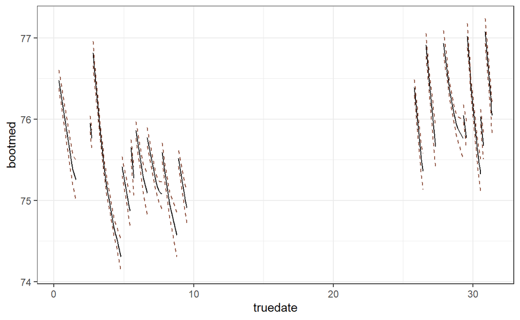

```r
ggplot( fast_sleep_cor, aes( x = truedate,
                             y = bootmed,
                             group = Episode#,
                             #color = time
                             )) +
  theme_bw() +
  geom_line() +
  geom_line(aes(y=bootlwr), color="salmon4",linetype="dashed") +
  geom_line(aes(y=bootupr), color="salmon4",linetype="dashed")
```

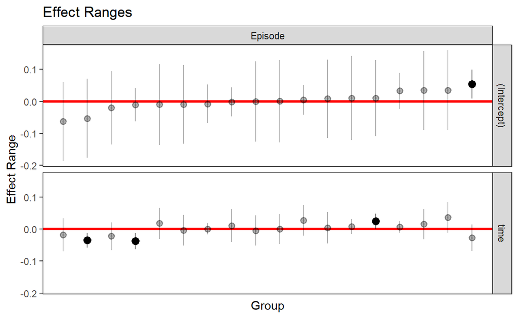

```r
plotREsim(REsim(mod_lmer, n.sims=2000))  # plot the interval estimates
```

```r
# pr <- fast_sleep_cor[!duplicated(fast_sleep_cor$Episode),]
# pr$time <- 8
# pr$pr8 <- predict(mod_cor, newdata = pr)
# plot(pr$Date_beginning,pr$pr8, type = "l") # random hatásokkal
# plot(smooth.spline(pr$Date_beginning,pr$pr8))
```